# CPS305 Fall 2019

## Lab 02 Report

## Sameer Naumani, Std ID 500703778

19/09/2019

# Introduction and Overall Comments

The goal of this lab is to explore the time complexity of various python methods of lists and dictionaries. In experiment 1 the goal was to verify that the get item and update item methods for dictionaries are O(1) constant time. This means the graphs produced should show horizontal lines, which denotes O(1).

The second experiment's objective was to explore the time complexities of the delete method for both lists and dictionaries. The expected result would be that lists would have a higher complexity than dictionaries.

Overall the expected results were verified and the experiments were successful. They took some time to run because of the nested loops and large amount of iterations.

## Solution for exercise 1

[figure not shown]

```python
# Verify Dictionary get method is O(1)
# Devise Experiment to verify get item and update item are O(1) for dictionaries

import matplotlib.pyplot as plt
import timeit
import random

#yl, ylacc = [], 0
yd, ydacc = [], 0
ydu, yduacc = [], 0
rng = range(10000,1000001,20000)
reps = 10
for i in rng:
    for j in range(reps):
        t = timeit.Timer("x.get(%d)"%random.randrange(i),"from __main__ import random,x")
        tupdate = timeit.Timer("x.update(g=4)", "from __main__ import x")
        x = {k:None for k in range(i)}
        ydacc += t.timeit(number=10)
        #print(ydacc)
        yduacc += tupdate.timeit(number=10)
    yd.append(ydacc/reps)
    ydu.append(ylpacc/reps)

x = rng
plt.xlabel('Size')
plt.ylabel('Time (in miliseconds)')
plt.plot(x, yd, 'g^', label="Dict get")
plt.plot(x, ydu, 'b+', label="Dict update")
plt.legend()
plt.show()
```

**Discussion of the Results**

In this excercise, the time complexities of the get and update methods are compared for dictionaries. They are both expected to return O(1) order of magnitude in the average case. Based on the following experiment both methods return a straight line as expected. This suggest it relatively takes the same time throughout or in other words constant time. That is why both lines are very linear.

## Solution for Exercise 2

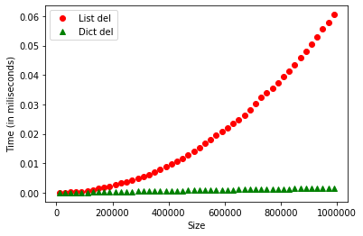

```python
# Python code and its output
import matplotlib.pyplot as plt
import timeit
import random

yl, ylacc = [], 0
yd, ydacc = [], 0

rng = range(10000,1000001,20000)
reps = 10
for i in rng:
    for j in range(reps):
        t = timeit.Timer("del x[random.randrange(%d)]"%i,"from __main__ import random,x")

        x = list(range(i))
        ylacc += t.timeit(number=7)

        x = {k:None for k in range(i)}
        ydacc += t.timeit(number=10)
    yl.append(ylacc/reps)
    yd.append(ydacc/reps)

x = rng
plt.xlabel('Size')
plt.ylabel('Time (in miliseconds)')
plt.plot(x, yl, 'ro', label="List del")
plt.plot(x, yd, 'g^', label="Dict del")
#plt.plot(x, ylp, 'b+', label="pop(0) list")
plt.legend()
plt.show()
```

**Discussion of the Results**

In this excercise, the time complexities of the delete method are compared between lists and dictionaries. It is clear that the list delete operation is of a greater time complexity than that of a dictionary. The Dictionary delete method of of constant time while the list operation is approximately O(n).